# Resumen de tablas

# IPI:

Qué es el IPI

El Índice de Producción Industrial (IPI) mide la evolución mensual de la actividad productiva de las ramas industriales, es decir, de las industrias extractivas, manufactureras y de producción y distribución de energía eléctrica, agua y gas y, por primera vez para la base 2010, también la división 36: Captación, depuración y distribución de agua, de la sección E de la CNAE-2009.

Este indicador refleja la evolución conjunta de la cantidad y de la calidad, eliminando la influencia de los precios.

Para conseguir el objetivo marcado por el Reglamento para la obtención de este  
indicador se selecciona una cesta de productos o bienes representativos de toda la  
industria y un panel de establecimientos industriales que fabriquen estos bienes y que serán los que facilitan los datos sobre las producciones mensuales realizadas.

Los cambios de base son importantes, no sólo por actualizar las ponderaciones, sino  
también para revisar la cesta de los productos y el panel de establecimientos (aunque en el panel se van sustituyendo las bajas que se producen por cierre de los  
establecimientos).

El objetivo del Índice de Producción es medir los cambios que se producen en el  
volumen, en términos de valor añadido

Dado que es un índice de volumen, las cantidades (tanto producidas como  
consumidas) **deben estar valoradas a precios del periodo base** .

El índice de producción es una medición teórica a la que hay que aproximarse  
mediante mediciones prácticas. En la práctica los siguientes valores son adecuados  
como sustitutos para la construcción de los índices:

1. Los valores de la producción bruta (deflactados).
2. Los volúmenes
3. El volumen de negocios (deflactado)
4. El insumo de trabajo
5. El insumo de materias primas
6. El insumo de energía

### ÍNDICES ELEMENTALES

El Índice de Producción Industrial base 2010 es un **índice de Laspeyres de base fija.** En el caso del IPI los agregados elementales son los productos más adecuados para aproximar la evolución de la actividad de cada una de las clases (cuatro dígitos) de las **secciones B, C, D** y división 36 de la CNAE 2009.

Para cada una de las ramas de actividad industrial, determinada a nivel de clase de la CNAE 2009, se obtiene, de la Encuesta Industrial Anual de Producto (EIAP, ya la tengo) correspondiente al año base del IPI, el valor de la producción de cada uno de los productos que según la PRODCOM están incluidos en esa clase. Una vez ordenados estos productos por  
su valor de producción se seleccionan los más importantes, hasta cubrir un porcentaje significativo del valor de la producción total en esa clase.  
Según las recomendaciones internacionales , en la práctica los siguientes valores son adecuados como sustitutos para la construcción de los índices: los valores de la producción bruta (deflactados), los volúmenes, el volumen de negocios (deflactado), el insumo de  
trabajo, el insumo de materias primas y el insumo de energía.

Se utilizan tres de estos métodos

- Los volúmenes

Productos que pertenecen a actividades con  
producciones homogéneas en cantidades físicas. Se solicita a los  
informantes las cantidades producidas en el mes del producto seleccionado,  
expresadas en Kilogramos, Toneladas, Metros, Es el método más utilizado, las actividades para las que  
se utiliza representan el 77% del VAB.

- Los valores de la producción bruta (deflactados).

productos de actividades con producciones heterogéneas o  
cambiantes. e solicita al establecimiento el valor de la producción de ese producto en el mes de referencia y posteriormente se deflacta utilizando el  
índice de precios más ajustado a ese producto. Los índice de precios para  
deflactar se obtienen de los Índices de Precios Industriales (IPRI) y de los Índices de Precios de Exportación de Productos Industriales (IPRIX). Se utilizan para  
ramas de actividad que representan el 21% del VAB.

- El insumo de trabajo

Este método se emplea para las actividades con productos con largo proceso de  
fabricación, únicos, etc (industria naval, ferroviaria y aeronáutica). Se utilizan en  
pocas ramas y representan el 2% del VAB.

### Formulación

TABLAS EN IPI:

- 2002 - 2018 Base 2015
- 2002 - 2017 Base 2010
- 2002 - 2013 Base 2005

Tabla utilizada: Base 2015 Índices:

- General
- Bienes de Consumo
- Bienes de Consumo Duraderos
- Bienes de Consumo no Duraderos
- Bienes Intermedios
- Bienes de Equipo
- Energía

### ÍNDICES AGREGADOS

Los índices agregados de las clases (cuatro dígitos de CNAE) se obtienen como suma ponderada de los índices elementales de los productos pertenecientes a dicha clase,  
ponderados en función del valor de la producción extraída de la de la Encuesta  
Industrial Anual de Productos (EIAP). sta encuesta no dispone de información del  
valor añadido generado en la producción de cada bien, pero sí del valor de la  
producción de cada uno.

### ÍNDICES CORREGIDOS DE EFECTOS ESTACIONALES Y DE EFECTOS DE CALENDARIO

Los Índices de Producción Industrial nacionales se publican corregidos de efectos  
estacionales y de calendario en base 2010.

El método empleado para la corrección de los efectos de calendario está basado,  
siguiendo el estándar del INE y de acuerdo a las recomendaciones de Eurostat, en  
modelos regARIMA (modelos de regresión con errores ARIMA estacionarios).

## Resumen

```r
summary(IPI)
```

```
     Index             BC_duraderos    BC_noduraderos   bienes_consumo   bienes_equipo
 Min.   :2002-01-01   Min.   : 44.72   Min.   : 81.13   Min.   : 80.86   Min.   : 69.27
 1st Qu.:2006-02-15   1st Qu.:105.04   1st Qu.: 98.43   1st Qu.: 98.81   1st Qu.:110.42
 Median :2010-04-01   Median :180.38   Median :103.39   Median :105.08   Median :177.65
 Mean   :2010-04-01   Mean   :215.89   Mean   :105.17   Mean   :107.19   Mean   :209.46
 3rd Qu.:2014-05-16   3rd Qu.:330.11   3rd Qu.:111.33   3rd Qu.:113.48   3rd Qu.:284.79
 Max.   :2018-07-01   Max.   :623.74   Max.   :146.85   Max.   :149.88   Max.   :551.45
 bienes_intermedios    energía          general
 Min.   : 83.34     Min.   : 67.07   Min.   : 89.22
 1st Qu.:100.94     1st Qu.: 89.65   1st Qu.:100.47
 Median :144.41     Median : 96.20   Median :110.51
 Mean   :180.94     Mean   : 95.69   Mean   :112.23
 3rd Qu.:271.17     3rd Qu.:102.10   3rd Qu.:122.62
 Max.   :337.93     Max.   :119.00   Max.   :143.22
```

## Primeros Datos

```r
class(IPI)
```

```
[1] "xts" "zoo"
```

```r
head(IPI)
```

```
           BC_duraderos BC_noduraderos bienes_consumo bienes_equipo bienes_intermedios energía general
2002-01-01      218.928        112.858        113.597       378.980            262.638  82.385 121.072
2002-02-01      162.819        105.532        105.032       409.328            254.697  70.767 112.442
2002-03-01      196.209        118.810        118.593       334.569            262.932  87.050 123.648
2002-04-01      224.780        118.009        118.712       405.628            270.873  77.104 121.973
2002-05-01      207.913        109.081        109.671       384.532            272.049  83.617 121.587
2002-06-01      190.357        108.966        109.077       374.909            257.932  88.546 122.102
```

Plot de datos

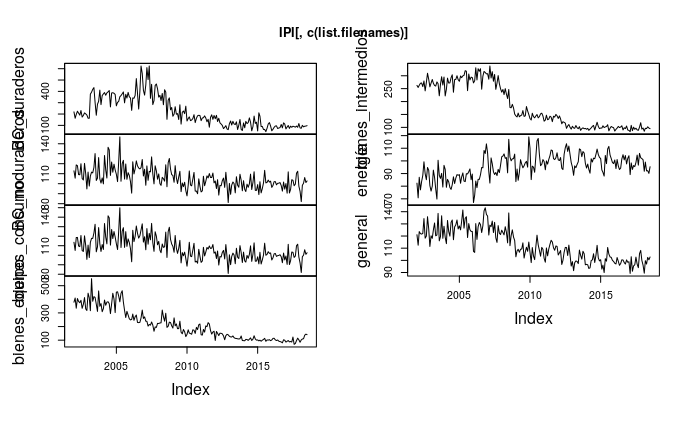

```r
plot.zoo(x = IPI[ ,c(list.filenames)])
```

Datos sin trend

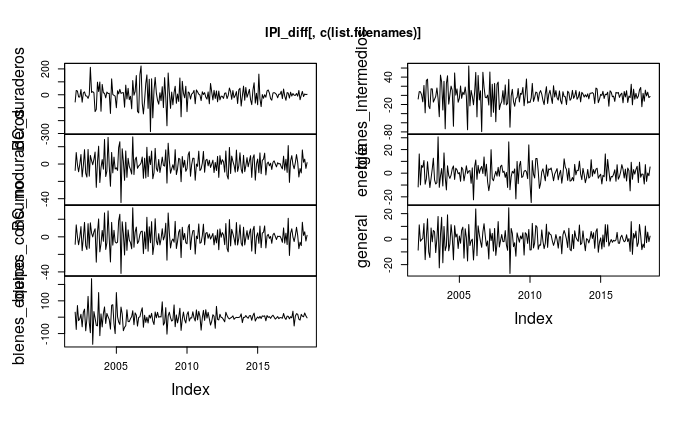

```r
IPI_diff<-diff(IPI)
plot.zoo(x = IPI_diff[ ,c(list.filenames)])
```

# IPRI

Índice de Precios Industriales 4

El Índice de Precios Industriales (IPRI) es una estadística cuyo principal objetivo es la medición de la evolución de los precios de la industria. Tiene como objetivo medir la evolución de los precios de los productos industriales , fabricados y vendidos en el mercado interior, en la primera etapa de su comercialización, es decir, desde el lado de la oferta (productor ). Los precios considerados para e l cálculo son los de venta a salida de fábrica, excluyendo los gastos de transporte y de comercialización y el IVA facturado.

Tiene la misma estructura que el IPI

- 2002 - 2018 Base 2015
- 2002 - 2017 Base 2010
- 2002 - 2013 Base 2005

Tabla utilizada: Base 2015 Índices:

- General
- Bienes de Consumo
- Bienes de Consumo Duraderos
- Bienes de Consumo no Duraderos
- Bienes Intermedios
- Bienes de Equipo
- Energía

## Resumen

```r
class(IPRI)
```

```
[1] "xts" "zoo"
```

```r
head(IPRI,3)
```

[output not shown]

```r
summary(IPRI)
```

[output not shown]

Plot de datos

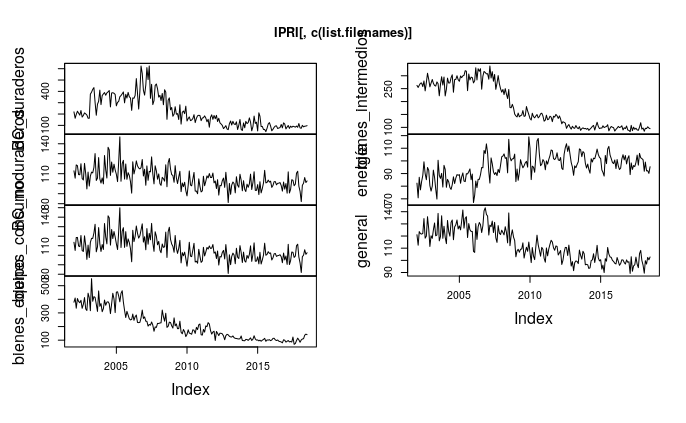

```r
plot.zoo(x = IPRI[ ,c(list.filenames)])
```

Plot de datos sin tendencia:

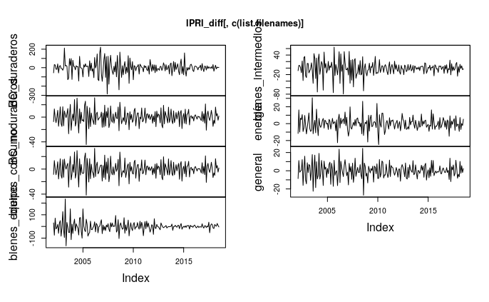

```r
IPRI_diff<-diff(IPRI)
plot.zoo(x = IPRI_diff[ ,c(list.filenames)])
```

# Encuesta Industrial de Empresa (EIE) (NO LAS HE PROCESADO)

proporciona información anual de las principales características estructurales de los diversos sectores de la industria en Canarias, permitiendo su comparación con los datos nacionales y de otras comunidades autónomas.

- Series anuales. Comunidades autónomas. 2015-2016. (Metodología 2015/2016):
  - Principales magnitudes estructurales y económicas de la industria según actividades principales (CNAE-2009) en Canarias por años.

    Esta tabla presenta datos del 2015-2016 por sector. Esta tabla es una mierda Intems de encuesta-> sector….
- Series anuales. Canarias. 2008-2014. (CNAE-2009)

  01 Principales agregados contables según agrupaciones de actividad. 02 Principales agregados contables según subagrupaciones de actividad. 03 Personas ocupadas y horas trabajadas según agrupaciones de actividad. 04 Personas ocupadas y horas trabajadas según subagrupaciones de actividad. 05 Procedencia geográfica de las compras según agrupaciones de actividad. 06 Destino geográfico de las ventas según agrupaciones de actividad.

  Macromagnitudes industriales de Canarias

  07 Según agrupaciones de actividad. 08 Según subagrupaciones de actividad.

# Encuesta Industrial Anual de Productos (EIAP)

## Producción por agrupaciones de actividad (CNAE-93)

### Serie 1993-2000 (millones de pesetas).

```r
head(EIAP_1993, 3)
```

```
            TOTAL Alimentación, bebidas y tabaco. (CNAE: 15-16) Textil y confección. (CNAE: 17-18)
1993-01-01 205244                                        134422                                965
1994-01-01 264069                                        177383                                 NA
1995-01-01 277618                                        170716                               1608
           Cuero y calzado. (CNAE: 19) Madera y corcho. (CNAE: 20)
1993-01-01                          NA                        1553
1994-01-01                           0                        1920
1995-01-01                           0                        3984
           Papel, artes gráficas y edición. (CNAE: 21-22)
1993-01-01                                          19833
1994-01-01                                          23975
1995-01-01                                          30389
           Coquerías, refino de petróleo y químicas. (CNAE: 23-24)
1993-01-01                                                    3619
1994-01-01                                                    4133
1995-01-01                                                    4008
           Manufacturas de corcho y plástico. (CNAE: 25) Productos minerales no metálicos. (CNAE: 26)
1993-01-01                                          5670                                        23589
1994-01-01                                          6697                                        27302
1995-01-01                                          8048                                        34991
           Producción, 1ª transformación y fundición de metales. (CNAE: 27)
1993-01-01                                                               NA
1994-01-01                                                               NA
1995-01-01                                                               NA
           Productos metálicos. (CNAE: 28) Maquinaria y equipo, óptica y similares. (CNAE: 29-30-33)
1993-01-01                            2725                                                      3885
1994-01-01                            5352                                                      4962
1995-01-01                            5847                                                      5448
           Material eléctrico y electrónico. (CNAE: 31-32) Material de transporte. (CNAE: 34-35)
1993-01-01                                              NA                                  5051
1994-01-01                                              NA                                  7042
1995-01-01                                              NA                                  6306
           Otras industrias manufactureras. (CNAE: 36)
1993-01-01                                        3048
1994-01-01                                        3294
1995-01-01                                        4307
```

```r
#summary y plot
summary(EIAP_1993)
```

```
     Index                TOTAL        Alimentación, bebidas y tabaco. (CNAE: 15-16)
 Min.   :1993-01-01   Min.   :205244   Min.   :134422
 1st Qu.:1994-10-01   1st Qu.:274231   1st Qu.:175716
 Median :1996-07-02   Median :322490   Median :190849
 Mean   :1996-07-02   Mean   :374834   Mean   :189419
 3rd Qu.:1998-04-02   3rd Qu.:419908   3rd Qu.:211992
 Max.   :2000-01-01   Max.   :688530   Max.   :222156

 Textil y confección. (CNAE: 17-18) Cuero y calzado. (CNAE: 19) Madera y corcho. (CNAE: 20)
 Min.   : 965                       Min.   :0                   Min.   :1553
 1st Qu.:1222                       1st Qu.:0                   1st Qu.:3468
 Median :1421                       Median :0                   Median :4476
 Mean   :1354                       Mean   :0                   Mean   :4922
 3rd Qu.:1553                       3rd Qu.:0                   3rd Qu.:7030
 Max.   :1608                       Max.   :0                   Max.   :8486
 NA's   :4                          NA's   :4
 Papel, artes gráficas y edición. (CNAE: 21-22) Coquerías, refino de petróleo y químicas. (CNAE: 23-24)
 Min.   :19833                                  Min.   :  3619
 1st Qu.:28786                                  1st Qu.:  4070
 Median :31310                                  Median :  4641
 Mean   :30189                                  Mean   : 61959
 3rd Qu.:34312                                  3rd Qu.: 74949
 Max.   :35952                                  Max.   :267415
                                                NA's   :1
 Manufacturas de corcho y plástico. (CNAE: 25) Productos minerales no metálicos. (CNAE: 26)
 Min.   : 5670                                 Min.   :23589
 1st Qu.: 6920                                 1st Qu.:33069
 Median : 8234                                 Median :47673
 Mean   : 8024                                 Mean   :50220
 3rd Qu.: 8902                                 3rd Qu.:65506
 Max.   :10278                                 Max.   :83932

 Producción, 1ª transformación y fundición de metales. (CNAE: 27) Productos metálicos. (CNAE: 28)
 Min.   : NA                                                      Min.   : 2725
 1st Qu.: NA                                                      1st Qu.: 5723
 Median : NA                                                      Median : 9125
 Mean   :NaN                                                      Mean   : 9991
 3rd Qu.: NA                                                      3rd Qu.:13662
 Max.   : NA                                                      Max.   :19226
 NA's   :8
```

[output cut: 8 more lines]

```
 Material eléctrico y electrónico. (CNAE: 31-32) Material de transporte. (CNAE: 34-35)
 Min.   :1297                                    Min.   : 5051
 1st Qu.:2325                                    1st Qu.: 6858
 Median :3384                                    Median : 8156
 Mean   :3042                                    Mean   : 8154
 3rd Qu.:3870                                    3rd Qu.: 9711
 Max.   :4333                                    Max.   :10747
 NA's   :3
 Otras industrias manufactureras. (CNAE: 36)
 Min.   :   0
 1st Qu.:2286
 Median :3800
 Mean   :3124
 3rd Qu.:4668
 Max.   :4883
```

#### Indicadores

```r
names(EIAP_1993)
```

```
 [1] "TOTAL"
 [2] "Alimentación, bebidas y tabaco. (CNAE: 15-16)"
 [3] "Textil y confección. (CNAE: 17-18)"
 [4] "Cuero y calzado. (CNAE: 19)"
 [5] "Madera y corcho. (CNAE: 20)"
 [6] "Papel, artes gráficas y edición. (CNAE: 21-22)"
 [7] "Coquerías, refino de petróleo y químicas. (CNAE: 23-24)"
 [8] "Manufacturas de corcho y plástico. (CNAE: 25)"
 [9] "Productos minerales no metálicos. (CNAE: 26)"
[10] "Producción, 1ª transformación y fundición de metales. (CNAE: 27)"
[11] "Productos metálicos. (CNAE: 28)"
[12] "Maquinaria y equipo, óptica y similares. (CNAE: 29-30-33)"
[13] "Material eléctrico y electrónico. (CNAE: 31-32)"
[14] "Material de transporte. (CNAE: 34-35)"
[15] "Otras industrias manufactureras. (CNAE: 36)"
```

### Serie 2001-2007 (miles de euros) (datos anuales)!

Faltan datos en estas series:

```r
head(EIAP_2001,3)
```

```
             TOTAL Alimentación, bebidas y tabaco. (CNAE: 15-16) Textil y confección. (CNAE: 17-18)
2001-01-01 3822723                                       1165081                               7905
2002-01-01 4156435                                       1251146                               8915
2003-01-01 4315099                                       1323409                              11853
           Cuero y calzado. (CNAE: 19) Madera y corcho. (CNAE: 20)
2001-01-01                           0                       47004
2002-01-01                           0                       48929
2003-01-01                           0                       49211
           Papel, artes gráficas y edición. (CNAE: 21-22)
2001-01-01                                         229331
2002-01-01                                         256036
2003-01-01                                         231468
           Coquerías, refino de petróleo y químicas. (CNAE: 23-24)
2001-01-01                                                 1461581
2002-01-01                                                 1383591
2003-01-01                                                 1436007
           Manufacturas de corcho y plástico. (CNAE: 25) Productos minerales no metálicos. (CNAE: 26)
2001-01-01                                         49479                                       522290
2002-01-01                                         49698                                       512100
2003-01-01                                         51346                                       545543
           Producción, 1ª transformación y fundición de metales. (CNAE: 27)
2001-01-01                                                               NA
2002-01-01                                                               NA
2003-01-01                                                               NA
           Productos metálicos. (CNAE: 28) Maquinaria y equipo, óptica y similares. (CNAE: 29-30-33)
2001-01-01                          133706                                                     67356
2002-01-01                          145059                                                     65339
2003-01-01                          165366                                                     83073
           Material eléctrico y electrónico. (CNAE: 31-32) Material de transporte. (CNAE: 34-35)
2001-01-01                                           19362                                 63972
2002-01-01                                           13258                                 64353
2003-01-01                                           13020                                 70406
           Otras industrias manufactureras. (CNAE: 36) Energía eléctrica, gas y vapor. (CNAE: 40)
2001-01-01                                          NA                                         NA
2002-01-01                                          NA                                         NA
2003-01-01                                          NA                                         NA
```

#### Summary

```r
#summary
summary(EIAP_2001)
```

```
     Index                TOTAL         Alimentación, bebidas y tabaco. (CNAE: 15-16)
 Min.   :2001-01-01   Min.   :3822723   Min.   :1165081
 1st Qu.:2002-07-02   1st Qu.:4235767   1st Qu.:1279099
 Median :2004-01-01   Median :4543486   Median :1313640
 Mean   :2004-01-01   Mean   :5037439   Mean   :1311949
 3rd Qu.:2005-07-02   3rd Qu.:5800826   3rd Qu.:1332464
 Max.   :2007-01-01   Max.   :6822677   Max.   :1481793

 Textil y confección. (CNAE: 17-18) Cuero y calzado. (CNAE: 19) Madera y corcho. (CNAE: 20)
 Min.   : 7905                      Min.   :0                   Min.   :47004
 1st Qu.: 8915                      1st Qu.:0                   1st Qu.:49070
 Median :11853                      Median :0                   Median :52111
 Mean   :11409                      Mean   :0                   Mean   :52645
 3rd Qu.:14048                      3rd Qu.:0                   3rd Qu.:56641
 Max.   :14324                      Max.   :0                   Max.   :57980
 NA's   :2
 Papel, artes gráficas y edición. (CNAE: 21-22) Coquerías, refino de petróleo y químicas. (CNAE: 23-24)
 Min.   :229331                                 Min.   :1383591
 1st Qu.:229922                                 1st Qu.:1448794
 Median :231468                                 Median :1667418
 Mean   :239521                                 Mean   :1915080
 3rd Qu.:246691                                 3rd Qu.:2417670
 Max.   :262623                                 Max.   :2621627

 Manufacturas de corcho y plástico. (CNAE: 25) Productos minerales no metálicos. (CNAE: 26)
 Min.   :49479                                 Min.   :510080
 1st Qu.:50522                                 1st Qu.:517195
 Median :53232                                 Median :534143
 Mean   :58652                                 Mean   :576699
 3rd Qu.:66146                                 3rd Qu.:614465
 Max.   :74513                                 Max.   :729353

 Producción, 1ª transformación y fundición de metales. (CNAE: 27) Productos metálicos. (CNAE: 28)
 Min.   :16423                                                    Min.   :133706
 1st Qu.:23492                                                    1st Qu.:155212
 Median :28187                                                    Median :176390
 Mean   :27141                                                    Mean   :189763
 3rd Qu.:31836                                                    3rd Qu.:218484
 Max.   :35768                                                    Max.   :270848
 NA's   :3
```

[output cut: 9 more lines]

```
 Min.   :13020                                   Min.   :63972
 1st Qu.:13740                                   1st Qu.:64353
 Median :18880                                   Median :70406
 Mean   :18592                                   Mean   :74155
 3rd Qu.:21137                                   3rd Qu.:75637
 Max.   :28488                                   Max.   :96405
                                                 NA's   :2
 Otras industrias manufactureras. (CNAE: 36) Energía eléctrica, gas y vapor. (CNAE: 40)
 Min.   :45805                               Min.   :566182
 1st Qu.:49132                               1st Qu.:566782
 Median :52677                               Median :567382
 Mean   :51893                               Mean   :695911
 3rd Qu.:55438                               3rd Qu.:760776
 Max.   :56414                               Max.   :954169
 NA's   :3                                   NA's   :4
```

#### Indicadores

```r
names(EIAP_2001)
```

```
 [1] "TOTAL"
 [2] "Alimentación, bebidas y tabaco. (CNAE: 15-16)"
 [3] "Textil y confección. (CNAE: 17-18)"
 [4] "Cuero y calzado. (CNAE: 19)"
 [5] "Madera y corcho. (CNAE: 20)"
 [6] "Papel, artes gráficas y edición. (CNAE: 21-22)"
 [7] "Coquerías, refino de petróleo y químicas. (CNAE: 23-24)"
 [8] "Manufacturas de corcho y plástico. (CNAE: 25)"
 [9] "Productos minerales no metálicos. (CNAE: 26)"
[10] "Producción, 1ª transformación y fundición de metales. (CNAE: 27)"
[11] "Productos metálicos. (CNAE: 28)"
[12] "Maquinaria y equipo, óptica y similares. (CNAE: 29-30-33)"
[13] "Material eléctrico y electrónico. (CNAE: 31-32)"
[14] "Material de transporte. (CNAE: 34-35)"
[15] "Otras industrias manufactureras. (CNAE: 36)"
[16] "Energía eléctrica, gas y vapor. (CNAE: 40)"
```

## Serie 2008-2017 (miles de euros) (datos anuales)!

```r
head(EIAP_2008,3)
```

```
             TOTAL Alimentación, bebidas y tabaco (CNAE: 10-11-12) Textil y confección (CNAE: 13-14)
2008-01-01 7315946                                         1446992                             13285
2009-01-01 5637992                                         1400705                             12443
2010-01-01 6170059                                         1321035                             14306
           Cuero y calzado (CNAE: 15) Madera y corcho (CNAE: 16)
2008-01-01                          0                      53649
2009-01-01                          0                      28956
2010-01-01                          0                      24037
           Papel, artes gráficas y reproducción de soportes grabados (CNAE: 17-18)
2008-01-01                                                                  199345
2009-01-01                                                                  181018
2010-01-01                                                                  176374
           Coquerías, refino, químicas y productos farmacéuticos (CNAE: 19-20-21)
2008-01-01                                                                2658609
2009-01-01                                                                1868810
2010-01-01                                                                2404952
           Manufacturas de caucho y plástico (CNAE: 22) Productos minerales no metálicos (CNAE: 23)
2008-01-01                                        60195                                      564601
2009-01-01                                        52248                                      304335
2010-01-01                                        51577                                      237434
           Producción, 1ª transformación y fundición de metales (CNAE: 24)
2008-01-01                                                           32585
2009-01-01                                                           22987
2010-01-01                                                           25053
           Productos metálicos (CNAE: 25)
2008-01-01                         214421
2009-01-01                         155263
2010-01-01                         116506
           Productos informáticos, electrónicos, ópticos y eléctricos (CNAE: 26-27)
2008-01-01                                                                    14121
2009-01-01                                                                     9722
2010-01-01                                                                     8135
           Maquinaria y equipo (CNAE: 28) Material de transporte (CNAE: 29-30)
2008-01-01                          20763                                 3986
2009-01-01                           7153                                 1768
2010-01-01                           3930                                 1548
           Muebles y otras industrias manufactureras (CNAE: 31-32)
2008-01-01                                                   52611
2009-01-01                                                   38431
2010-01-01                                                   37836
           Reparación e instalación de maquinaria y equipo (CNAE: 33)
2008-01-01                                                     270787
2009-01-01                                                     195848
2010-01-01                                                     179046
           Producción de energía eléctrica, gas y vapor (CNAE: 35)
2008-01-01                                                 1709998
2009-01-01                                                 1358304
2010-01-01                                                 1568289
```

```r
#summary y plot
summary(EIAP_2008)
```

```
     Index                TOTAL         Alimentación, bebidas y tabaco (CNAE: 10-11-12)
 Min.   :2008-01-01   Min.   :3269996   Min.   :1316118
 1st Qu.:2010-04-02   1st Qu.:4101352   1st Qu.:1345553
 Median :2012-07-02   Median :5904016   Median :1388190
 Mean   :2012-07-02   Mean   :5459830   Mean   :1382890
 3rd Qu.:2014-10-01   3rd Qu.:6198689   3rd Qu.:1417264
 Max.   :2017-01-01   Max.   :7315946   Max.   :1446992

 Textil y confección (CNAE: 13-14) Cuero y calzado (CNAE: 15) Madera y corcho (CNAE: 16)
 Min.   : 8454                     Min.   :0                  Min.   : 8343
 1st Qu.:11526                     1st Qu.:0                  1st Qu.: 9189
 Median :12790                     Median :0                  Median :10636
 Mean   :12141                     Mean   :0                  Mean   :18389
 3rd Qu.:13248                     3rd Qu.:0                  3rd Qu.:23042
 Max.   :14306                     Max.   :0                  Max.   :53649
 NA's   :4                         NA's   :4
 Papel, artes gráficas y reproducción de soportes grabados (CNAE: 17-18)
 Min.   :176374
 1st Qu.:182688
 Median :185644
 Mean   :188541
 3rd Qu.:196112
 Max.   :203994

 Coquerías, refino, químicas y productos farmacéuticos (CNAE: 19-20-21)
 Min.   :  22469
 1st Qu.: 495589
 Median :1953923
 Mean   :1615981
 3rd Qu.:2378980
 Max.   :2926184

 Manufacturas de caucho y plástico (CNAE: 22) Productos minerales no metálicos (CNAE: 23)
 Min.   :29204                                Min.   :154740
 1st Qu.:34656                                1st Qu.:171639
 Median :40848                                Median :197864
 Mean   :42238                                Mean   :239538
 3rd Qu.:50238                                3rd Qu.:235067
 Max.   :60195                                Max.   :564601

```

[output cut: 32 more lines]

```
 Reparación e instalación de maquinaria y equipo (CNAE: 33)
 Min.   :179046
 1st Qu.:214224
 Median :260365
 Mean   :250168
 3rd Qu.:278502
 Max.   :316616

 Producción de energía eléctrica, gas y vapor (CNAE: 35)
 Min.   :1079644
 1st Qu.:1283112
 Median :1597864
 Mean   :1539289
 3rd Qu.:1702810
 Max.   :2011966
```

#### Indicadores

```r
names(EIAP_2008)
```

```
 [1] "TOTAL"
 [2] "Alimentación, bebidas y tabaco (CNAE: 10-11-12)"
 [3] "Textil y confección (CNAE: 13-14)"
 [4] "Cuero y calzado (CNAE: 15)"
 [5] "Madera y corcho (CNAE: 16)"
 [6] "Papel, artes gráficas y reproducción de soportes grabados (CNAE: 17-18)"
 [7] "Coquerías, refino, químicas y productos farmacéuticos (CNAE: 19-20-21)"
 [8] "Manufacturas de caucho y plástico (CNAE: 22)"
 [9] "Productos minerales no metálicos (CNAE: 23)"
[10] "Producción, 1ª transformación y fundición de metales (CNAE: 24)"
[11] "Productos metálicos (CNAE: 25)"
[12] "Productos informáticos, electrónicos, ópticos y eléctricos (CNAE: 26-27)"
[13] "Maquinaria y equipo (CNAE: 28)"
[14] "Material de transporte (CNAE: 29-30)"
[15] "Muebles y otras industrias manufactureras (CNAE: 31-32)"
[16] "Reparación e instalación de maquinaria y equipo (CNAE: 33)"
[17] "Producción de energía eléctrica, gas y vapor (CNAE: 35)"
```

# Estadística de producción y consumo de energía eléctrica

Producción bruta, disponibilidad y consumo de energía eléctrica por islas de Canarias y periodos. Series mensuales. Islas. 1991 Enero - 2018 Agosto

*Existen datos para cada Isla. Por ahora solo se verán los datos para Canarias Unidad de Medida MW/h

```r
head(EN,3)
```

```
           Energía eléctrica disponible Producción bruta de energía eléctrica
1991-01-01                      301.147                               313.455
1991-02-01                      267.718                               281.065
1991-03-01                      288.719                               304.697
           Consumo de energía eléctrica
1991-01-01                      296.299
1991-02-01                      269.583
1991-03-01                      238.431
```

```r
str(EN)
```

```
An ‘xts’ object on 1991-01-01/2018-08-01 containing:
  Data: num [1:332, 1:3] 301 268 289 281 287 ...
 - attr(*, "dimnames")=List of 2
  ..$ : NULL
  ..$ : chr [1:3] "Energía eléctrica disponible" "Producción bruta de energía eléctrica" "Consumo de energía eléctrica"
  Indexed by objects of class: [Date] TZ: UTC
  xts Attributes:
 NULL
```

```r
summary(EN)
```

```
     Index            Energía eléctrica disponible Producción bruta de energía eléctrica
 Min.   :1991-01-01   Min.   :267.7                Min.   :281.1
 1st Qu.:1997-11-23   1st Qu.:429.5                1st Qu.:421.5
 Median :2004-10-16   Median :670.3                Median :651.7
 Mean   :2004-10-15   Mean   :595.2                Mean   :582.9
 3rd Qu.:2011-09-08   3rd Qu.:739.2                3rd Qu.:721.5
 Max.   :2018-08-01   Max.   :812.6                Max.   :812.1

 Consumo de energía eléctrica
 Min.   :238.4
 1st Qu.:394.2
 Median :618.2
 Mean   :549.1
 3rd Qu.:685.4
 Max.   :757.7
 NA's   :8
```

### Plot

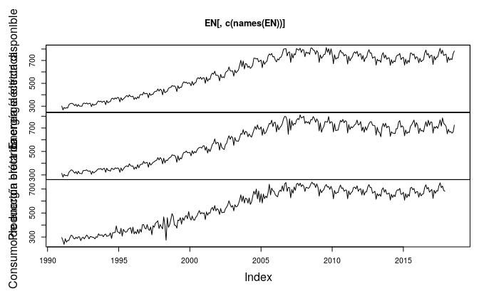

```r
plot.zoo(x = EN[ ,c(names(EN))])
```

# Recopilación de estadísticas de productos derivados del petróleo

## Series mensuales del precio del petróleo. 1986-2018

```r
summary(precio_gas)
```

```
     Index            Precio del petróleo (barril Brent)
 Min.   :1986-01-01   Min.   :  951
 1st Qu.:1994-03-01   1st Qu.: 1841
 Median :2002-05-01   Median : 2833
 Mean   :2002-05-01   Mean   : 4464
 3rd Qu.:2010-07-01   3rd Qu.: 6496
 Max.   :2018-09-01   Max.   :13284
```

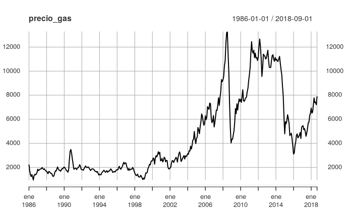

```r
plot.xts(precio_gas)
```

## Series mensuales de consumos. Provincias de Canarias. 2003-2018

Datos para Las Palmas, Santa Cruz, y Canarias Datos para Galosina(95, 97 y 98) Gasoleo (A, B yC) y Fuelóleo Unidad de medida: Tonelada Tipo de dato: Flujo

```r
summary(consumo_gas)
```

```
     Index               FUELÓLEO         GASÓLEO         GASOLINA
 Min.   :2003-01-01   Min.   :  3468   Min.   :45680   Min.   :35561
 1st Qu.:2006-11-16   1st Qu.: 55116   1st Qu.:57259   1st Qu.:41236
 Median :2010-10-01   Median : 94769   Median :69848   Median :43699
 Mean   :2010-10-01   Mean   : 79817   Mean   :67364   Mean   :44489
 3rd Qu.:2014-08-16   3rd Qu.:110229   3rd Qu.:74994   3rd Qu.:48233
 Max.   :2018-07-01   Max.   :140673   Max.   :98643   Max.   :67671
```

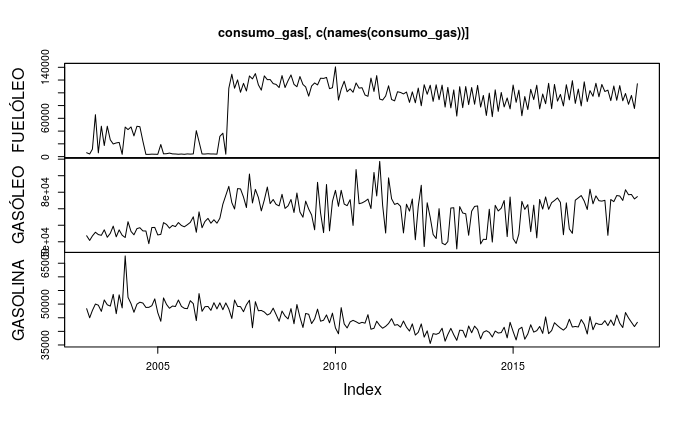

```r
plot.zoo(x = consumo_gas[ ,c(names(consumo_gas))])
```